# Lab 4

# Palmer Penguins Modeling

Import the Palmer Penguins dataset and print out the first few rows.

Suppose we want to predict `bill_depth_mm` using the other variables in the dataset.

Which variables would we need to **dummify**?

```python
!pip install palmerpenguins
```

```
Downloading palmerpenguins-0.1.4-py3-none-any.whl (17 kB)
```

```python
from palmerpenguins import load_penguins
penguins = load_penguins()
df = penguins
df.head()
```

|  | species | island | bill_length_mm | bill_depth_mm | flipper_length_mm | body_mass_g | sex | year |
| --- | --- | --- | --- | --- | --- | --- | --- | --- |
| 0 | Adelie | Torgersen | 39.1 | 18.7 | 181.0 | 3750.0 | male | 2007 |
| 1 | Adelie | Torgersen | 39.5 | 17.4 | 186.0 | 3800.0 | female | 2007 |
| 2 | Adelie | Torgersen | 40.3 | 18.0 | 195.0 | 3250.0 | female | 2007 |
| 3 | Adelie | Torgersen | NaN | NaN | NaN | NaN | NaN | 2007 |
| 4 | Adelie | Torgersen | 36.7 | 19.3 | 193.0 | 3450.0 | female | 2007 |

Let’s use `bill_length_mm` to predict `bill_depth_mm`. Prepare your data and fit the following models on the entire dataset:

- Simple linear regression (e.g. straight-line) model
- Quadratic (degree 2 polynomial) model
- Cubic (degree 3 polynomial) model
- Degree 10 polynomial model

Make predictions for each model and plot your fitted models on the scatterplot.

```python
import pandas as pd
from pandas import get_dummies
```

```python
pd.get_dummies(df).head()
```

|  | bill_length_mm | bill_depth_mm | flipper_length_mm | body_mass_g | year | species_Adelie | species_Chinstrap | species_Gentoo | island_Biscoe | island_Dream | island_Torgersen | sex_female | sex_male |
| --- | --- | --- | --- | --- | --- | --- | --- | --- | --- | --- | --- | --- | --- |
| 0 | 39.1 | 18.7 | 181.0 | 3750.0 | 2007 | True | False | False | False | False | True | False | True |
| 1 | 39.5 | 17.4 | 186.0 | 3800.0 | 2007 | True | False | False | False | False | True | True | False |
| 2 | 40.3 | 18.0 | 195.0 | 3250.0 | 2007 | True | False | False | False | False | True | True | False |
| 3 | NaN | NaN | NaN | NaN | 2007 | True | False | False | False | False | True | False | False |
| 4 | 36.7 | 19.3 | 193.0 | 3450.0 | 2007 | True | False | False | False | False | True | True | False |

```python
from sklearn.linear_model import LinearRegression
lr = LinearRegression()
```

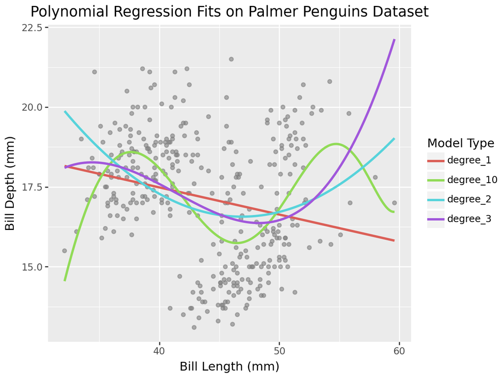

```python
import pandas as pd
import numpy as np
from plotnine import ggplot, aes, geom_point, geom_line, labs, theme_minimal
from sklearn.linear_model import LinearRegression
from sklearn.preprocessing import PolynomialFeatures
from palmerpenguins import load_penguins

# Load and clean dataset
penguins = load_penguins()
penguins = penguins.dropna(subset=['bill_length_mm', 'bill_depth_mm'])

# Prepare feature and target
X = penguins[['bill_length_mm']].values
y = penguins['bill_depth_mm'].values

# Degrees to model
degrees = [1, 2, 3, 10]

# Prepare a smooth X range for predictions
X_fit = np.linspace(X.min(), X.max(), 200).reshape(-1, 1)

# DataFrame to hold fitted results
fits = pd.DataFrame({'bill_length_mm': X_fit.flatten()})

# Generate model fits for each polynomial degree
for degree in degrees:
    poly = PolynomialFeatures(degree=degree, include_bias=False)
    X_poly = poly.fit_transform(X)
    X_fit_poly = poly.transform(X_fit)

    model = LinearRegression()
    model.fit(X_poly, y)
    fits[f'degree_{degree}'] = model.predict(X_fit_poly)

# Melt into long format for ggplot
fits_long = fits.melt(id_vars='bill_length_mm', var_name='model', value_name='bill_depth_mm')

# Base scatter plot
p = (
    ggplot(penguins, aes(x='bill_length_mm', y='bill_depth_mm'))
    + geom_point(alpha=0.6, color='gray')
    + geom_line(fits_long, aes(x='bill_length_mm', y='bill_depth_mm', color='model'), size=1.2)
    + labs(
        title='Polynomial Regression Fits on Palmer Penguins Dataset',
        x='Bill Length (mm)',
        y='Bill Depth (mm)',
        color='Model Type'
    )
)

p
```

- Are any of the models above underfitting the data? If so, which ones and how can you tell?
- Are any of thhe models above overfitting the data? If so, which ones and how can you tell?
- Which of the above models do you think fits the data best and why?

The straight line is underfitting the data. It doesnt take into account the shape of the scatterplot and has a large sum of squares. The degree 10 model is definitely overfitting the model because it is trying to capture every point. I would say Model 3 fits the data the best, given that it captures most of the points but not all of them.